# simulate_data2

In this document, I’ll go through making a tree-based model and logistic regression model for datasets where we have no difference between the synthetic and confidential data, and a series of datasets where there are differences. I’ll compare different discriminant-based metrics on these models. Finally, I’ll try to put the findings into a figure. This is using Aaron’s new functions in the syntheval package.

```r
library(tidyverse)
library(devtools)
load_all('../syntheval')
```

```
ℹ Loading syntheval
```

```r
library(syntheval)
library(tidymodels)
library(vip)
library(tidysynthesis)
library(MASS)
library(dplyr)
library(ggpubr)
```

```r
set.seed(101)
n=10000 # number of samples
corr=.7 # correlation
p = 10 # number of variables

generate_cat <- function(cont){
  as_tibble(cont>0, n = 10)*1
}

generate_postsynth <- function(data){
  list(
    synthetic_data = data,
    jth_synthesis_time = data.frame(
      variable = factor(colnames(data.frame(data)))
    )
  )  %>%
  structure(class = "postsynth")
}
```

All variations on the input data

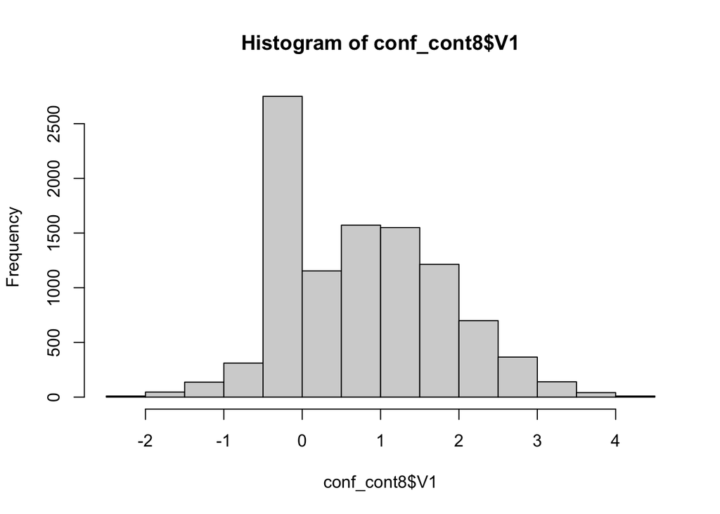

```r
# Same distribution
vcov = matrix(corr, p, p) + diag(1-corr, p, p) # vcov matrix, p on all off-diagonal variables
means = rep(0,p) # mean vector
conf_cont1 = as_tibble(mvrnorm(means, vcov, n = n), n = p)
synth_cont1 = generate_postsynth(as_tibble(mvrnorm(means, vcov, n = n), n=p))

conf_cat1 = generate_cat(conf_cont1)
synth_cat1 = generate_postsynth(generate_cat(synth_cont1[[1]]))

# larger variances, slightly off means
vcov = matrix(corr, p, p) + diag(1-corr, p, p) # vcov matrix, p on all off-diagonal variables
means = rep(0,p) # mean vector
conf_cont2 = as_tibble(mvrnorm(means, vcov, n = n), n=p)
means = sample(c(-.2,.2), 10, replace = T) # mean vector
vcov = matrix(2*corr, p, p) + diag(4-2*corr, p, p) # vcov matrix, p on all off-diagonal variables
synth_cont2 = generate_postsynth(as_tibble(mvrnorm(means, vcov, n = n), n=p))

conf_cat2 = generate_cat(conf_cont2)
synth_cat2 = generate_postsynth(generate_cat(synth_cont2[[1]]))

# one variable centered at wrong value
vcov = matrix(corr, p, p) + diag(1-corr, p, p) # vcov matrix, p on all off-diagonal variables
means = rep(0,p) # mean vector
conf_cont3 = as_tibble(mvrnorm(means, vcov, n = n), n=p)
means[1] = 2
synth_cont3 = generate_postsynth(as_tibble(mvrnorm(means, vcov, n = n), n=p))

conf_cat3 = generate_cat(conf_cont3)
synth_cat3 = generate_postsynth(generate_cat(synth_cont3[[1]]))

# relationship reversed (between V1 and everything else)
vcov = matrix(corr, p, p) + diag(1-corr, p, p) # vcov matrix, p on all off-diagonal variables
means = rep(0,p) # mean vector
conf_cont4 = as_tibble(mvrnorm(means, vcov, n = n), n=p)
vcov[1,2:p] = -rep(corr, p-1)
vcov[2:p,1] = -rep(corr, p-1)
synth_cont4 = generate_postsynth(as_tibble(mvrnorm(means, vcov, n = n), n=p))

conf_cat4 = generate_cat(conf_cont4)
synth_cat4 = generate_postsynth(generate_cat(synth_cont4[[1]]))

# continuous case where one variable should always be larger than the other
vcov = matrix(corr, p, p) + diag(1-corr, p, p)
vcov[1,1] = 3
means = rep(0,p) # mean vector
conf_cont5 = as_tibble(mvrnorm(means, vcov, n = n), n=p)
conf_cont5$V2 = conf_cont5$V1 + abs(rnorm(5, 3^.5, n = n))

synth_cont5 = as_tibble(mvrnorm(means, vcov, n = n), n=p)
synth_cont5$V2 = rnorm(5,3^.5, n = n)
synth_cont5 = generate_postsynth(synth_cont5)

# categorical case where synthetic data stop preserving variation (ignore some heterogeneity)
vcov = matrix(corr, p, p) + diag(1-corr, p, p)
means = rep(0, p)
conf_cat6 = generate_cat(as_tibble(mvrnorm(means, vcov, n = n), n=p)) # sometimes (rarely, V1 and V2 are unequal)
synth_cat6 = conf_cat6
synth_cat6$V2 = synth_cat6$V1
synth_cat6 = generate_postsynth(synth_cat6)

# categorical case with nested variables
vcov = matrix(corr, p, p) + diag(1-corr, p, p)
means = rep(0, p)
conf_cat7 = generate_cat(as_tibble(mvrnorm(means, vcov, n = n), n=p)) #
conf_cat7$V3 = ifelse(conf_cat7$V1==1 & conf_cat7$V2 == 1, rbinom(sum(conf_cat7$V1==1 & conf_cat7$V2 == 1), 1, .7), 0)
# check this is .7: mean(conf_cat7[conf_cat7$V1==1 & conf_cat7$V2 == 1,]$V3)
# check this is 0: mean(conf_cat7[!(conf_cat7$V1==1 & conf_cat7$V2 == 1),]$V3)
synth_cat7 = conf_cat7
synth_cat7$V3 = rnorm(n, mean(conf_cat7$V3), sqrt(cov(conf_cat7)[3,3]))
synth_cat7 = generate_postsynth(synth_cat7)

# spike that synthetic data doesn't reproduce
vcov = matrix(corr, p, p) + diag(1-corr, p, p)
means = rep(1, p)
conf_cont8 = as_tibble(mvrnorm(means, vcov, n = n), n=p)
conf_cont8$V1 = ifelse(rbinom(n, 1, .2) == 1, 0, conf_cont8$V1)
means[1] = mean(conf_cont8$V1)
vcov = cov(conf_cont8)
synth_cont8 = generate_postsynth(as_tibble(mvrnorm(means, vcov, n=n),n=p))
hist(conf_cont8$V1)
```

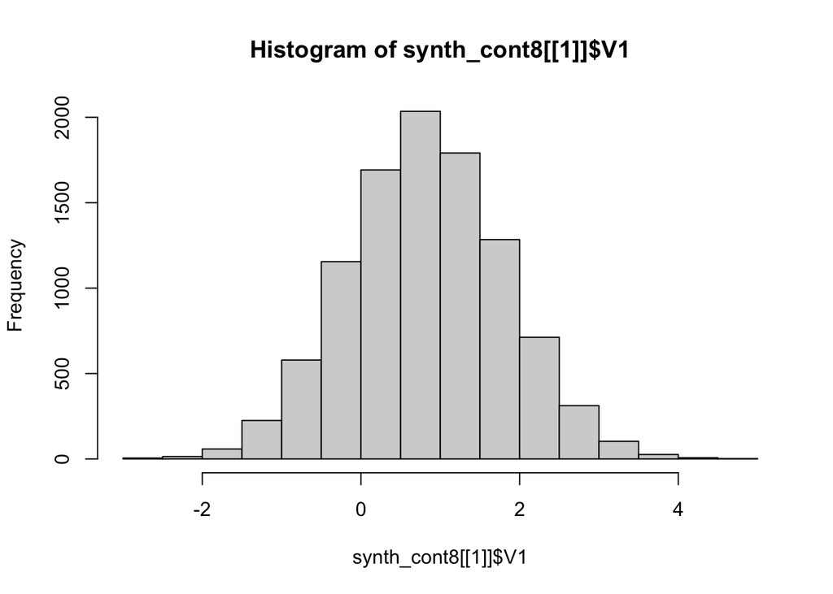

```r
hist(synth_cont8[[1]]$V1)
```

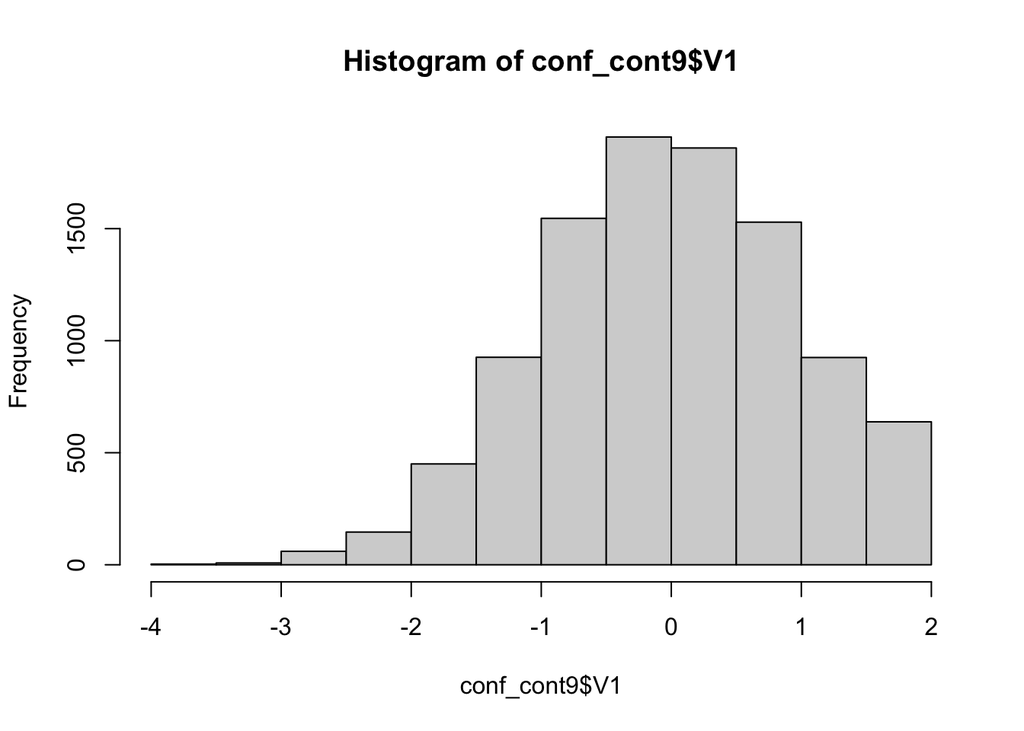

```r
# truncation that synthetic data doesn't respect
vcov = matrix(corr, p, p) + diag(1-corr, p, p)
means = rep(0, p)
conf_cont9 = as_tibble(mvrnorm(means, vcov, n = n), n=p)
conf_cont9$V1 = ifelse(conf_cont9$V1 >2, 2, conf_cont9$V1)
hist(conf_cont9$V1)
```

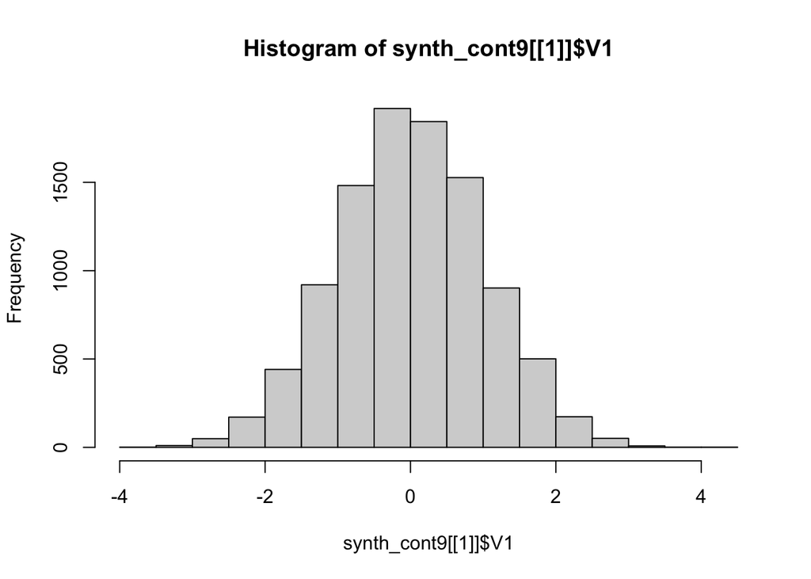

```r
synth_cont9 = generate_postsynth(as_tibble(mvrnorm(means, vcov, n = nrow(conf_cont9)), n=p))
hist(synth_cont9[[1]]$V1)
```